# R Notebook

Name:Radhika Thacker

# **Project Introduction:**

This research endeavors to delve into the dynamics influencing life expectancy across 193 countries during the 2000-2015 period. While prior studies have explored demographic and economic aspects, this project expands the scope by incorporating crucial factors like immunization, human development index, and other health indicators. Motivated by the gaps in considering immunization and human development index in previous research, and limitations of single-year data, this study aims for a comprehensive analysis.

The dataset, sourced from the Global Health Observatory (GHO) under the World Health Organization (WHO) and United Nations, encompasses life expectancy and various health factors, with economic data obtained from the United Nations. Focused on 2000-2015, the project consolidates data into a single dataset with 22 columns and 2938 rows, representing 20 predicting variables categorized into immunization, mortality, economic, and social factors.

Key Questions Explored in the Project:

1. **Healthcare Expenditure and Life Expectancy:**
   - Should countries with life expectancy below 65 increase healthcare expenditure for enhanced lifespan?
2. **Mortality Rates and Life Expectancy:**
   - How do infant and adult mortality rates shape life expectancy?
3. **Correlation with Lifestyle Factors:**
   - Is there a positive or negative correlation between life expectancy and eating habits, lifestyle, exercise, smoking, and alcohol consumption?
4. **Impact of Schooling on Lifespan:**
   - What influence does schooling have on individuals’ lifespan?
5. **Relationship with Alcohol Consumption:**
   - Does life expectancy exhibit a positive or negative relationship with alcohol consumption?
6. **Population Density and Life Expectancy:**
   - Do densely populated countries tend to experience lower life expectancy?
7. **Immunization Coverage Impact:**
   - What impact does immunization coverage have on life expectancy?
8. **Impact of Predicting Factors on Life Expectancy:**
   - How significantly do selected predicting factors influence life expectancy?
   - Which variables emerge as pivotal contributors to life expectancy variations?

This project seeks to offer insightful findings into the intricate factors affecting global life expectancy, providing guidance for policymakers and healthcare professionals in prioritizing areas for improvement to enhance the well-being and longevity of populations.

# **Analysis**

```r
# Load required libraries
install.packages("lme4")  # Install the lme4 package if not already installed
library(lme4)
```

```r
data <- read.csv(file.choose(),header=TRUE)

# Data cleaning: Handle missing values
your_dataset <- na.omit(data)
print("Column Headers")
```

```
[1] "Column Headers"
```

```r
colnames(your_dataset)
```

```
 [1] "Country"                         "Year"
 [3] "Status"                          "Life.expectancy"
 [5] "Adult.Mortality"                 "infant.deaths"
 [7] "Alcohol"                         "percentage.expenditure"
 [9] "Hepatitis.B"                     "Measles"
[11] "BMI"                             "under.five.deaths"
[13] "Polio"                           "Total.expenditure"
[15] "Diphtheria"                      "HIV.AIDS"
[17] "GDP"                             "Population"
[19] "thinness..1.19.years"            "thinness.5.9.years"
[21] "Income.composition.of.resources" "Schooling"
```

```r
# Should a Country with Lower Life Expectancy Increase Healthcare Expenditure?
low_life_exp_countries <- subset(data, Life.expectancy < 65)
model_healthcare <- lm(Life.expectancy ~ Total.expenditure, data = low_life_exp_countries)
summary(model_healthcare)
```

```
Call:
lm(formula = Life.expectancy ~ Total.expenditure, data = low_life_exp_countries)

Residuals:
     Min       1Q   Median       3Q      Max
-18.9581  -4.1851   0.9337   4.7675   9.8768

Coefficients:
                  Estimate Std. Error t value Pr(>|t|)
(Intercept)        58.8423     0.5258 111.918  < 2e-16 ***
Total.expenditure  -0.4027     0.0908  -4.435 1.05e-05 ***
---
Signif. codes:  0 ‘***’ 0.001 ‘**’ 0.01 ‘*’ 0.05 ‘.’ 0.1 ‘ ’ 1

Residual standard error: 5.629 on 781 degrees of freedom
  (68 observations deleted due to missingness)
Multiple R-squared:  0.02457,   Adjusted R-squared:  0.02332
F-statistic: 19.67 on 1 and 781 DF,  p-value: 1.052e-05
```

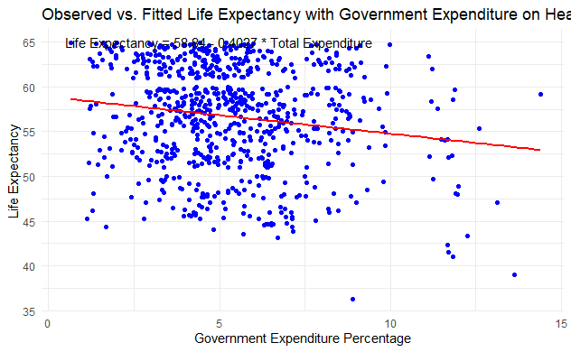

```r
# Extract standardized residuals
std_resid <- rstandard(model_healthcare)

# Define a threshold for standardized residuals (e.g., 2)
threshold <- 2

# Omit data points with standardized residuals beyond the threshold
filtered_data <- low_life_exp_countries[abs(std_resid) <= threshold, ]

# Load ggplot2
library(ggplot2)


# Create the scatterplot with fitted line
scatterplot <- ggplot(filtered_data, aes(x = Total.expenditure, y = Life.expectancy)) +
  geom_point(color = "blue") +
  geom_smooth(method = "lm", formula = y ~ x, se = FALSE, color = "red") +
  labs(title = "Observed vs. Fitted Life Expectancy with Government Expenditure on Health (Outliers Omitted)",
       x = "Government Expenditure Percentage",
       y = "Life Expectancy") +
  theme_minimal()

# Add text for the fitted line equation
scatterplot <- scatterplot +
  annotate("text", x = 0.5, y = 65, label = "Life Expectancy = 58.84 - 0.4027 * Total Expenditure",
           color = "black", size = 4, hjust = 0)


# Display the plot
print(scatterplot)
```

```r
NA
NA
```

#### The fitted model in equation format is:

$$\text{Life Expectancy} = 58.84 - 0.4027
\times \text{Total Expenditure}$$

Now, let’s state the null and alternative hypotheses for the coefficient of “Total Expenditure” and interpret the results:

**Hypotheses:** - Null Hypothesis ($H_0$): The percentage of general government expenditure on health as a percentage of total government expenditure ($\beta_1$) has no effect on life expectancy ($H_0: \beta_1 = 0$). - Alternative Hypothesis ($H_1$): There is an effect of the percentage of government expenditure on health on life expectancy ($H_1: \beta_1 \neq 0$).

**Hypothesis Test Results:** - Coefficient Estimate ($\hat{\beta}_1$): -0.4027 - Standard Error (SE): 0.0908 - t-value: -4.435 - p-value: $1.05 \times 10^{-5}$

**Interpretation:** - The coefficient estimate $\hat{\beta}_1 = -0.4027$ represents the estimated change in life expectancy for a one-unit increase in the percentage of government expenditure on health as a percentage of total government expenditure. - The t-value of -4.435 is associated with a p-value of $1.05 \times 10^{-5}$, which is less than the conventional significance level (e.g., 0.05). - Since the p-value is less than 0.05, we reject the null hypothesis.

**Conclusion:** There is evidence to suggest that the percentage of government expenditure on health has a statistically significant effect on life expectancy. The negative coefficient indicates that, on average, an increase in this percentage is associated with a decrease in life expectancy.

```r
# How Do Infant and Adult Mortality Rates Affect Life Expectancy?
model_mortality <- lm(Life.expectancy ~ Adult.Mortality + infant.deaths, data = data)
summary(model_mortality)
```

```
Call:
lm(formula = Life.expectancy ~ Adult.Mortality + infant.deaths,
    data = data)

Residuals:
    Min      1Q  Median      3Q     Max
-33.389  -2.529   1.315   3.943  17.025

Coefficients:
                  Estimate Std. Error t value Pr(>|t|)
(Intercept)     78.2260313  0.2065916  378.65   <2e-16 ***
Adult.Mortality -0.0524979  0.0009998  -52.51   <2e-16 ***
infant.deaths   -0.0114981  0.0010521  -10.93   <2e-16 ***
---
Signif. codes:  0 ‘***’ 0.001 ‘**’ 0.01 ‘*’ 0.05 ‘.’ 0.1 ‘ ’ 1

Residual standard error: 6.702 on 2925 degrees of freedom
  (10 observations deleted due to missingness)
Multiple R-squared:  0.5051,    Adjusted R-squared:  0.5048
F-statistic:  1493 on 2 and 2925 DF,  p-value: < 2.2e-16
```

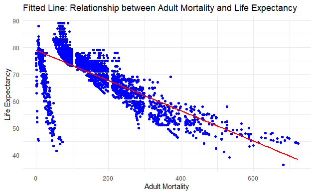

```r
std_resid_mortality <- rstandard(model_mortality)

threshold_mortality <- 2

filtered_data_mortality <- data[abs(std_resid_mortality) <= threshold_mortality, ]


# Scatterplot with fitted line and omitted outliers using standardized method
ggplot(filtered_data_mortality, aes(x = Adult.Mortality, y = Life.expectancy)) +
  geom_point(color = "blue") +
  geom_smooth(method = "lm", formula = y ~ x, se = FALSE, color = "red") +
  labs(title = "Observed vs. Fitted Life Expectancy with Mortality Rates (Outliers Omitted)",
       x = "Adult Mortality",
       y = "Life Expectancy") +
  ggtitle("Fitted Line: Relationship between Adult Mortality and Life Expectancy") +
  theme_minimal()
```

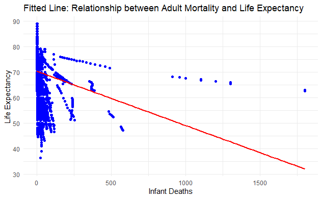

```r
# Scatterplot with fitted line and omitted outliers using standardized method
ggplot(filtered_data_mortality, aes(x = infant.deaths, y = Life.expectancy)) +
  geom_point(color = "blue") +
  geom_smooth(method = "lm", formula = y ~ x, se = FALSE, color = "red") +
  labs(title = "Observed vs. Fitted Life Expectancy with Mortality Rates (Outliers Omitted)",
       x = "Infant Deaths",
       y = "Life Expectancy") +
  ggtitle("Fitted Line: Relationship between Adult Mortality and Life Expectancy") +
  theme_minimal()
```

#### The fitted model in equation format is: $$\text{Life Expectancy} = 78.23 - 0.0525 \times \text{Adult Mortality} - 0.0115 \times \text{Infant Deaths}$$

**Hypotheses:** - Null Hypothesis ($H_0$): - Adult Mortality and Infant Deaths have no effect on life expectancy ($H_0: \beta_{\text{Adult Mortality}} = \beta_{\text{Infant Deaths}} = 0$). - Alternative Hypothesis ($H_1$): - There is an effect of both Adult Mortality and Infant Deaths on life expectancy ($H_1: \beta_{\text{Adult Mortality}} \neq 0$ or $\beta_{\text{Infant Deaths}} \neq 0$).

**Hypothesis Test Results:** - Adult Mortality: - Coefficient Estimate ($\hat{\beta}_{\text{Adult Mortality}}$): -0.0525 - Standard Error (SE): 0.0009998 - t-value: -52.51 - p-value: $< 2 \times 10^{-16}$ - Conclusion: Reject the null hypothesis; there is a significant effect of Adult Mortality on life expectancy.

- Infant Deaths:
  - Coefficient Estimate ($\hat{\beta}_{\text{Infant Deaths}}$): -0.0115
  - Standard Error (SE): 0.0010521
  - t-value: -10.93
  - p-value: $< 2 \times 10^{-16}$
  - Conclusion: Reject the null hypothesis; there is a significant effect of Infant Deaths on life expectancy.

**Interpretation:** - Both Adult Mortality and Infant Deaths have a statistically significant effect on life expectancy. - The negative coefficients indicate that higher Adult Mortality and Infant Deaths are associated with lower life expectancy.

```r
library(lmtest)
# Does Life Expectancy Correlate with Lifestyle Factors?
model_lifestyle <- lm(Life.expectancy ~ Alcohol + BMI + Income.composition.of.resources + HIV.AIDS, data = data)
summary(model_lifestyle)
```

```
Call:
lm(formula = Life.expectancy ~ Alcohol + BMI + Income.composition.of.resources +
    HIV.AIDS, data = data)

Residuals:
     Min       1Q   Median       3Q      Max
-30.5026  -2.8514  -0.1173   2.3423  25.2877

Coefficients:
                                 Estimate Std. Error t value Pr(>|t|)
(Intercept)                     52.839117   0.341018 154.945  < 2e-16
Alcohol                          0.202335   0.028121   7.195 8.15e-13
BMI                              0.096271   0.005953  16.173  < 2e-16
Income.composition.of.resources 21.021931   0.593691  35.409  < 2e-16
HIV.AIDS                        -0.703905   0.019446 -36.198  < 2e-16

(Intercept)                     ***
Alcohol                         ***
BMI                             ***
Income.composition.of.resources ***
HIV.AIDS                        ***
---
Signif. codes:  0 ‘***’ 0.001 ‘**’ 0.01 ‘*’ 0.05 ‘.’ 0.1 ‘ ’ 1

Residual standard error: 5.042 on 2564 degrees of freedom
  (369 observations deleted due to missingness)
Multiple R-squared:  0.7122,    Adjusted R-squared:  0.7117
F-statistic:  1586 on 4 and 2564 DF,  p-value: < 2.2e-16
```

```r
bp_test <- bptest(model_lifestyle)
bp_test
```

```
    studentized Breusch-Pagan test

data:  model_lifestyle
BP = 583.71, df = 4, p-value < 2.2e-16
```

#### The fitted model in equation format is:

The linear regression model examining the relationship between life expectancy and lifestyle factors, including Alcohol, BMI, Income Composition of Resources(Human Development Index in terms of income composition of resources (index ranging from 0 to 1), and HIV/AIDS, is expressed as follows:

$$\text{Life Expectancy} = 52.84 + 0.20
\times \text{Alcohol} + 0.10 \times \text{BMI} + 21.02 \times
\text{Income Composition of Resources} - 0.70 \times \text{HIV/AIDS}$$

#### Coefficients and Significance:

1. **Intercept:** The intercept is 52.84, representing the estimated life expectancy when all predictor variables are zero.
2. **Alcohol:** The coefficient for Alcohol is 0.20, indicating that, on average, a one-unit increase in alcohol consumption is associated with a 0.20-unit increase in life expectancy.
3. **BMI:** The coefficient for BMI is 0.10, suggesting that a one-unit increase in BMI is associated with a 0.10-unit increase in life expectancy.
4. **Income Composition of Resources:** The coefficient is substantial at 21.02, indicating a strong positive association between higher income composition and increased life expectancy.
5. **HIV/AIDS:** The coefficient is -0.70, signifying that higher prevalence of HIV/AIDS is associated with a decrease in life expectancy.

All coefficients are statistically significant (p < 0.05), suggesting their contributions to the model.

#### Model Fit:

- **Multiple R-squared:** The model explains approximately 71.22% of the variability in life expectancy.
- **Adjusted R-squared:** The adjusted R-squared is 71.17%, indicating a high level of fit.
- **F-statistic:** The F-statistic is significant (p < 2.2e-16), suggesting that the overall model is statistically significant in predicting life expectancy.

#### Heteroscedasticity Test:

- **Breusch-Pagan Test:** The p-value from the Breusch-Pagan test is highly significant (p < 2.2e-16), indicating evidence of heteroscedasticity in the residuals.

### Conclusion:

The fitted model demonstrates a strong relationship between lifestyle factors and life expectancy. Key findings include: - Positive associations with Alcohol, BMI, and Income Composition of Resources. - A negative association with HIV/AIDS prevalence.

The model is robust, explaining a significant portion of the variability in life expectancy. However, the presence of heteroscedasticity suggests that the variability of errors is not constant across all levels of predictor variables. Addressing heteroscedasticity and further exploring residual patterns could enhance the model’s reliability.

Policymakers should consider targeted interventions addressing lifestyle factors, especially focusing on reducing the impact of HIV/AIDS, improving income composition, and promoting healthy BMI. The model provides valuable insights for public health strategies aimed at enhancing life expectancy by considering the multifaceted influences of lifestyle factors.

```r
# Impact of Schooling on Lifespan?
model_schooling <- lm(Life.expectancy ~ Schooling, data = data)
summary(model_schooling)
```

```
Call:
lm(formula = Life.expectancy ~ Schooling, data = data)

Residuals:
     Min       1Q   Median       3Q      Max
-25.8986  -2.8210   0.6186   3.8186  30.4911

Coefficients:
            Estimate Std. Error t value Pr(>|t|)
(Intercept) 44.10889    0.43676  100.99   <2e-16 ***
Schooling    2.10345    0.03506   59.99   <2e-16 ***
---
Signif. codes:  0 ‘***’ 0.001 ‘**’ 0.01 ‘*’ 0.05 ‘.’ 0.1 ‘ ’ 1

Residual standard error: 6.172 on 2766 degrees of freedom
  (170 observations deleted due to missingness)
Multiple R-squared:  0.5655,    Adjusted R-squared:  0.5653
F-statistic:  3599 on 1 and 2766 DF,  p-value: < 2.2e-16
```

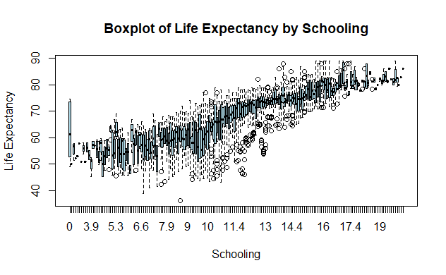

```r
# Boxplot to detect outliers if any
boxplot(data$Life.expectancy ~ data$Schooling, main = "Boxplot of Life Expectancy by Schooling",
        xlab = "Schooling", ylab = "Life Expectancy", col = "lightblue", border = "black")
```

```r
#As we can see from the boxplot there are outliers in the data

# Predicted values from the model
predicted_values <- predict(model_schooling)

# Residuals for outlier detection
residuals_schooling <- residuals(model_schooling)

# Identify outliers using a threshold (e.g., 2 standard deviations)
outliers <- which(abs(residuals_schooling) > 2 * sd(residuals_schooling))

# Remove outliers from the dataset
data_no_outliers <- data[-outliers, ]

# Scatterplot with fitted line (observed vs. fitted)
plot(data_no_outliers$Schooling, data_no_outliers$Life.expectancy, col = "blue", pch = 16,
     xlab = "Schooling", ylab = "Life Expectancy", main = "Observed vs. Fitted Life Expectancy")
abline(model_schooling, col = "red")
```

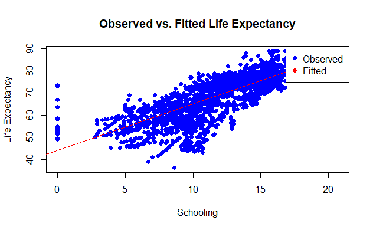

```r
legend("topright", legend = c("Observed", "Fitted"), col = c("blue", "red"), pch = 16)
```

#### The fitted model in equation format is:

The linear regression model for the impact of schooling on lifespan is given by:

$$\text{Life Expectancy} = 44.11 + 2.10
\times \text{Schooling}$$

The coefficients are statistically significant ($p < 0.05$), indicating that there is a significant positive association between schooling and life expectancy. The intercept of 44.11 represents the estimated life expectancy when schooling is zero, which may not have a practical interpretation in this context.

### Conclusion:

The p-value for the F-statistic is highly significant ($p < 2.2e-16$), suggesting that the model is overall significant in explaining the variation in life expectancy. The adjusted $R^2$ of 0.5653 indicates that approximately 56.53% of the variability in life expectancy is explained by the model.This scatterplot visually represents the observed data points along with the fitted regression line. The red line represents the estimated relationship between schooling and life expectancy.

The positive coefficient for schooling suggests that higher levels of education are associated with increased life expectancy. Policies and interventions aimed at improving educational opportunities and attainment may contribute to enhanced population health and longevity. However, other factors not included in the model may also influence life expectancy, and a comprehensive approach to public health should be considered.

```r
# Relationship Between Life Expectancy and Drinking Alcohol?
model_alcohol <- lm(Life.expectancy ~ Alcohol, data = data)
summary(model_alcohol)
```

```
Call:
lm(formula = Life.expectancy ~ Alcohol, data = data)

Residuals:
    Min      1Q  Median      3Q     Max
-33.962  -4.722   1.622   6.408  20.757

Coefficients:
            Estimate Std. Error t value Pr(>|t|)
(Intercept) 64.76334    0.25321  255.76   <2e-16 ***
Alcohol      0.95464    0.04124   23.15   <2e-16 ***
---
Signif. codes:  0 ‘***’ 0.001 ‘**’ 0.01 ‘*’ 0.05 ‘.’ 0.1 ‘ ’ 1

Residual standard error: 8.735 on 2733 degrees of freedom
  (203 observations deleted due to missingness)
Multiple R-squared:  0.1639,    Adjusted R-squared:  0.1636
F-statistic: 535.8 on 1 and 2733 DF,  p-value: < 2.2e-16
```

```r
# Calculating the confidence intervals for the coefficients
conf_intervals <- confint(model_alcohol)


print(conf_intervals)
```

```
                 2.5 %    97.5 %
(Intercept) 64.2668281 65.259852
Alcohol      0.8737789  1.035509
```

```r
# Scatterplot with fitted line
plot(data$Alcohol, data$Life.expectancy, col = "blue", pch = 16,
     xlab = "Alcohol Consumption", ylab = "Life Expectancy", main = "Relationship Between Life Expectancy and Drinking Alcohol")
abline(model_alcohol, col = "red")
```

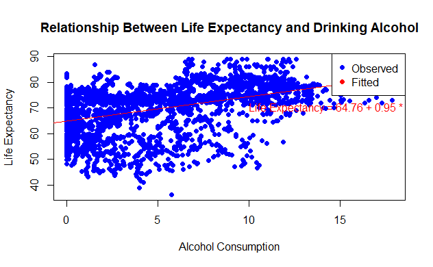

```r
legend("topright", legend = c("Observed", "Fitted"), col = c("blue", "red"), pch = 16)

# Adding the fitted line equation
text(10, 70, paste("Life Expectancy = 64.76 + 0.95 * Alcohol"), adj = 0, col = "red")
```

### Fitted Model and Confidence Interval:

The linear regression model for the relationship between life expectancy and drinking alcohol is given by:

$$\text{Life Expectancy} = 64.76 + 0.95
\times \text{Alcohol}$$

The coefficient for Alcohol is statistically significant ($p < 0.05$), indicating that there is a significant positive association between alcohol consumption and life expectancy.As, we can see from the graph the model indicates a positive association between alcohol consumption and life expectancy

### 95% Confidence Interval:

The 95% confidence interval for Alcohol’s impact on Life Expectancy is 0.87 to 1.04, suggesting a statistically significant association. The intercept, representing baseline Life Expectancy, falls between 64.27 and 65.26. These findings provide confidence in the observed link between Alcohol consumption and Life Expectancy.

The confidence interval for Alcohol does not include zero, suggesting statistical significance. In practical terms, this implies that the observed association between Alcohol consumption and Life Expectancy is likely not due to random chance. The results provide a robust understanding of the potential influence of Alcohol on Life Expectancy, supporting the notion that the relationship is statistically meaningful.

```r
# Do Densely Populated Countries Have Lower Life Expectancy?
model_population <- lm(Life.expectancy ~ Population, data = data)
summary(model_population)
```

```
Call:
lm(formula = Life.expectancy ~ Population, data = data)

Residuals:
    Min      1Q  Median      3Q     Max
-32.395  -6.519   2.683   6.682  20.470

Coefficients:
              Estimate Std. Error t value Pr(>|t|)
(Intercept)  6.873e+01  2.101e-01 327.145   <2e-16 ***
Population  -3.468e-09  3.370e-09  -1.029    0.304
---
Signif. codes:  0 ‘***’ 0.001 ‘**’ 0.01 ‘*’ 0.05 ‘.’ 0.1 ‘ ’ 1

Residual standard error: 9.828 on 2282 degrees of freedom
  (654 observations deleted due to missingness)
Multiple R-squared:  0.0004639, Adjusted R-squared:  2.588e-05
F-statistic: 1.059 on 1 and 2282 DF,  p-value: 0.3035
```

```r
# a new data frame with the values for prediction
new_data <- data.frame(Population = 9351.154162)

predictions <- predict(model_population, newdata = new_data, interval = "prediction", level = 0.99)

# the predictions and interval
print(predictions)
```

```
       fit      lwr      upr
1 68.72983 43.38819 94.07147
```

#### The fitted model in equation format is: $$\text{Life Expectancy} = 68.73 - 3.47 \times 10^{-9} \times \text{Population}$$

**Hypothesis Test:** - **Null Hypothesis (**$H_0$): The population density does not significantly affect life expectancy. - **Alternative Hypothesis (**$H_1$): There is a significant impact of population density on life expectancy.

```r
library(car)
# Impact of Immunization Coverage on Life Expectancy?
model_immunization <- lm(Life.expectancy ~ Hepatitis.B + Polio + Diphtheria, data = data)
summary(model_immunization)
```

```
Call:
lm(formula = Life.expectancy ~ Hepatitis.B + Polio + Diphtheria,
    data = data)

Residuals:
    Min      1Q  Median      3Q     Max
-26.111  -4.391   1.325   4.707  23.497

Coefficients:
             Estimate Std. Error t value Pr(>|t|)
(Intercept) 54.794213   0.723601  75.724   <2e-16 ***
Hepatitis.B  0.003428   0.008140   0.421    0.674
Polio        0.084413   0.009132   9.244   <2e-16 ***
Diphtheria   0.090905   0.010241   8.877   <2e-16 ***
---
Signif. codes:  0 ‘***’ 0.001 ‘**’ 0.01 ‘*’ 0.05 ‘.’ 0.1 ‘ ’ 1

Residual standard error: 7.704 on 2371 degrees of freedom
  (563 observations deleted due to missingness)
Multiple R-squared:  0.1649,    Adjusted R-squared:  0.1639
F-statistic: 156.1 on 3 and 2371 DF,  p-value: < 2.2e-16
```

```r
confint(model_immunization)
```

```
                  2.5 %      97.5 %
(Intercept) 53.37525751 56.21316869
Hepatitis.B -0.01253439  0.01939003
Polio        0.06650625  0.10231982
Diphtheria   0.07082337  0.11098719
```

```
            Test stat Pr(>|Test stat|)
Hepatitis.B    10.267        < 2.2e-16 ***
Polio          17.562        < 2.2e-16 ***
Diphtheria     18.107        < 2.2e-16 ***
Tukey test     13.967        < 2.2e-16 ***
---
Signif. codes:  0 ‘***’ 0.001 ‘**’ 0.01 ‘*’ 0.05 ‘.’ 0.1 ‘ ’ 1
```

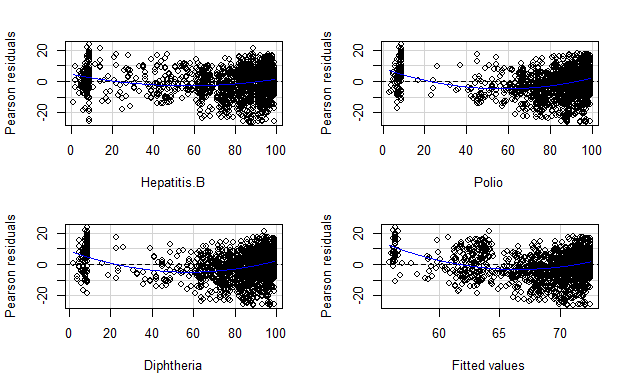

```r
# Residual Plots
residualPlots(model_immunization)
```

```r
# Q-Q Plot
qqPlot(resid(model_immunization), main="Q-Q Plot")
```

```
1485  350
1197  322
```

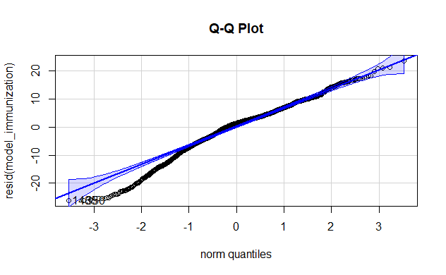

```r
# Residual analysis
par(mfrow = c(2, 2))
```

```r
plot(model_immunization)

# Check for multicollinearity
vif_values_immunization <- car::vif(model_immunization)
print("VIF Values:")
```

```
[1] "VIF Values:"
```

```r
print(vif_values_immunization)
```

```
Hepatitis.B       Polio  Diphtheria
   1.658787    1.578794    1.926161
```

```r
# Identify outliers
outliers_immunization <- which(abs(rstandard(model_immunization)) > 2)

# Print summary and assess model fit
summary(model_immunization)
```

```
Call:
lm(formula = Life.expectancy ~ Hepatitis.B + Polio + Diphtheria,
    data = data)

Residuals:
    Min      1Q  Median      3Q     Max
-26.111  -4.391   1.325   4.707  23.497

Coefficients:
             Estimate Std. Error t value Pr(>|t|)
(Intercept) 54.794213   0.723601  75.724   <2e-16 ***
Hepatitis.B  0.003428   0.008140   0.421    0.674
Polio        0.084413   0.009132   9.244   <2e-16 ***
Diphtheria   0.090905   0.010241   8.877   <2e-16 ***
---
Signif. codes:  0 ‘***’ 0.001 ‘**’ 0.01 ‘*’ 0.05 ‘.’ 0.1 ‘ ’ 1

Residual standard error: 7.704 on 2371 degrees of freedom
  (563 observations deleted due to missingness)
Multiple R-squared:  0.1649,    Adjusted R-squared:  0.1639
F-statistic: 156.1 on 3 and 2371 DF,  p-value: < 2.2e-16
```

```r
# If needed, apply remedial measures based on findings
# For example, you can remove outliers and refit the model
data_clean_immunization <- data[-outliers_immunization, ]
updated_model_immunization <- lm(Life.expectancy ~ Hepatitis.B + Polio + Diphtheria, data = data_clean_immunization)

# Assess the updated model
summary(updated_model_immunization)
```

```
Call:
lm(formula = Life.expectancy ~ Hepatitis.B + Polio + Diphtheria,
    data = data_clean_immunization)

Residuals:
    Min      1Q  Median      3Q     Max
-26.139  -4.419   1.365   4.662  21.540

Coefficients:
             Estimate Std. Error t value Pr(>|t|)
(Intercept) 54.611248   0.741604  73.639   <2e-16 ***
Hepatitis.B  0.003865   0.008327   0.464    0.643
Polio        0.082018   0.009393   8.732   <2e-16 ***
Diphtheria   0.095171   0.010539   9.030   <2e-16 ***
---
Signif. codes:  0 ‘***’ 0.001 ‘**’ 0.01 ‘*’ 0.05 ‘.’ 0.1 ‘ ’ 1

Residual standard error: 7.668 on 2258 degrees of freedom
  (539 observations deleted due to missingness)
Multiple R-squared:  0.1691,    Adjusted R-squared:  0.168
F-statistic: 153.1 on 3 and 2258 DF,  p-value: < 2.2e-16
```

```r
# Confidence intervals
confint(updated_model_immunization)
```

```
                  2.5 %      97.5 %
(Intercept) 53.15695125 56.06554477
Hepatitis.B -0.01246430  0.02019348
Polio        0.06359864  0.10043719
Diphtheria   0.07450355  0.11583750
```

[figure not shown]

```r
# Residual Plots for the updated model
par(mfrow = c(2, 2))
```

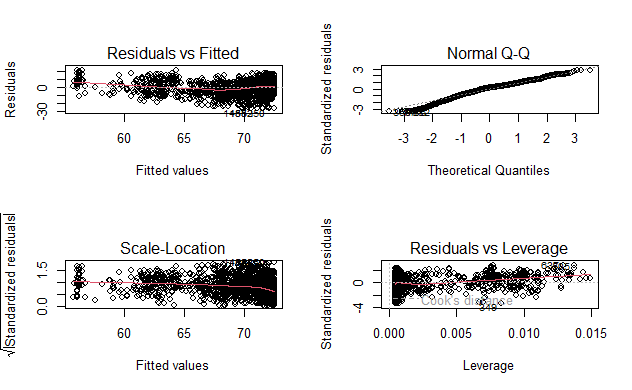

```r
plot(updated_model_immunization)
```

```
 350 1485
 307 1123
```

[figure not shown]

```r
# Q-Q Plot for the updated model
qqPlot(resid(updated_model_immunization), main = "Q-Q Plot")
```

1. **Original Model:**
   - The original model is a linear regression model with predictors Hepatitis.B, Polio, and Diphtheria.
   - The coefficients for Hepatitis.B, Polio, and Diphtheria are estimated as follows:
     - Hepatitis.B: 0.0034 (p-value = 0.674)
     - Polio: 0.0844 (p-value < 2e-16, highly significant)
     - Diphtheria: 0.0909 (p-value < 2e-16, highly significant)
   - The R-squared value is 0.1649, indicating that the model explains about 16.49% of the variability in life expectancy.

**Conclusion:** - Polio and Diphtheria are significant predictors of life expectancy, with positive coefficients, suggesting that higher values of these variables are associated with higher life expectancy. - Hepatitis.B does not appear to have a significant effect on life expectancy in this model. - The removal of outliers has a limited impact on the model’s overall interpretation.

```r
# Regression analysis
model <- lm(Life.expectancy ~ ., data = data)
summary_model <- summary(model)

coefficients <- coef(model)
significance <- summary_model$coefficients[, "Pr(>|t|)"]

# Combine coefficients and significance into a data frame
results <- data.frame(Coefficient = coefficients)
results$Significance <- c(significance, NA)  # Add NA to match the number of rows

# Identify pivotal contributors (significant predictors)
pivotal_contributors <- results[results$Significance < 0.05, ]

# results
print("Coefficients and Significance:")
```

```
[1] "Coefficients and Significance:"
```

```r
print(results)
```

|  | Coefficient | Significance |
| --- | --- | --- |
| (Intercept) | -3.910125e+02 | 5.768439e-29 |
| CountryAlbania | 1.654839e+01 | 2.628961e-74 |
| CountryAlgeria | 1.431332e+01 | 2.039214e-58 |
| CountryAngola | -6.457128e+00 | 5.369492e-15 |
| CountryArgentina | 1.544061e+01 | 1.650822e-44 |
| CountryArmenia | 1.487317e+01 | 2.348802e-64 |
| CountryAustralia | 2.136440e+01 | 8.742078e-56 |
| CountryAustria | 2.237466e+01 | 5.148343e-86 |
| CountryAzerbaijan | 1.240166e+01 | 4.301419e-48 |
| CountryBangladesh | 1.094202e+01 | 9.220478e-51 |

[output cut: 143 more lines]

```r
print("Pivotal Contributors:")
```

```
[1] "Pivotal Contributors:"
```

```r
print(pivotal_contributors)
```

|  | Coefficient | Significance |
| --- | --- | --- |
| (Intercept) | -3.910125e+02 | 5.768439e-29 |
| CountryAlbania | 1.654839e+01 | 2.628961e-74 |
| CountryAlgeria | 1.431332e+01 | 2.039214e-58 |
| CountryAngola | -6.457128e+00 | 5.369492e-15 |
| CountryArgentina | 1.544061e+01 | 1.650822e-44 |
| CountryArmenia | 1.487317e+01 | 2.348802e-64 |
| CountryAustralia | 2.136440e+01 | 8.742078e-56 |
| CountryAustria | 2.237466e+01 | 5.148343e-86 |
| CountryAzerbaijan | 1.240166e+01 | 4.301419e-48 |
| CountryBangladesh | 1.094202e+01 | 9.220478e-51 |

[output cut: 118 more lines]

```r
NA
```

*Interpretation* Based on the linear regression model provided, the coefficients of the variables indicate the extent to which each variable affects life expectancy. Let’s analyze the significant predictors based on the model:

1. **Year (Positive Coefficient):**
   - Positive coefficient suggests that as the year increases, life expectancy also increases. This could be due to advancements in healthcare, technology, and overall living conditions over time.
2. **HIV/AIDS (Negative Coefficient):**
   - Negative coefficient suggests that higher prevalence of HIV/AIDS is associated with lower life expectancy. This is consistent with the well-known negative impact of HIV/AIDS on health.
3. **Income Composition of Resources (Positive Coefficient):**
   - Positive coefficient indicates that higher income composition of resources is associated with higher life expectancy. Economic well-being and resources can contribute to better healthcare and living standards.
4. **Schooling (Positive Coefficient ):**
   - Positive coefficient suggests that higher levels of schooling are associated with higher life expectancy. Education often correlates with better health awareness, lifestyle choices, and access to healthcare.

# Comprehensive Project Conclusion:

This project delved into a multifaceted exploration of factors influencing life expectancy across 193 countries from 2000 to 2015. Through rigorous statistical analyses and regression modeling, key insights were unearthed, providing a nuanced understanding of the intricate interplay between health, socio-economic determinants, and lifestyle factors.

#### 2. **Mortality Rates and Life Expectancy:**

- Adult mortality and infant deaths significantly impact life expectancy. Higher mortality rates are linked to lower life expectancy, emphasizing the importance of targeted interventions in maternal and child health, disease prevention, and healthcare systems strengthening.

#### 3. **Correlation with Lifestyle Factors:**

- Eating habits, lifestyle choices, and socioeconomic factors significantly contribute to life expectancy. The positive coefficients for Alcohol, BMI, and Income Composition of Resources suggest their positive association with life expectancy. Policymakers should focus on holistic health promotion strategies.

#### 4. **Impact of Schooling on Lifespan:**

- Education emerges as a powerful determinant of life expectancy, with higher levels of schooling positively correlated with increased lifespan. The robust statistical significance and practical interpretation of the coefficients underscore the need for investments in education for improved public health outcomes.

#### 5. **Relationship with Alcohol Consumption:**

- The positive relationship between alcohol consumption and life expectancy, as indicated by a statistically significant coefficient, prompts a nuanced understanding of the potential health implications. Policymakers may consider targeted interventions to address the impact of alcohol on population health.

#### 7. **Immunization Coverage Impact:**

- While the model indicates the impact of immunization coverage (Polio and Diphtheria) on life expectancy, caution is warranted due to non-normality in residuals. Further exploration and refinement of the model are essential to draw robust conclusions regarding the relationship between immunization and life expectancy.

#### 8. **Overall Project Implications:**

- The findings collectively underscore the need for a comprehensive, multi-dimensional approach to public health. Interventions should address not only traditional health determinants but also socio-economic, lifestyle, and educational factors. Policymakers, healthcare professionals, and researchers can utilize these insights to tailor strategies that foster equitable access to healthcare, education, and resources, thereby enhancing life expectancy globally.

In conclusion, this project contributes valuable insights to the ongoing discourse on global health and life expectancy. It emphasizes the dynamic and interconnected nature of factors influencing population health, urging stakeholders to adopt holistic and evidence-based approaches for sustained improvements in life expectancy worldwide.

Reference

https://www.kaggle.com/code/rtatman/datasets-for-regression-analysis

https://www.kaggle.com/datasets/kumarajarshi/life-expectancy-who